# Boston crime data

## How to explain criminality in Boston? June 29 2021

### First, let us have a look at how violence is spread across Boston districts

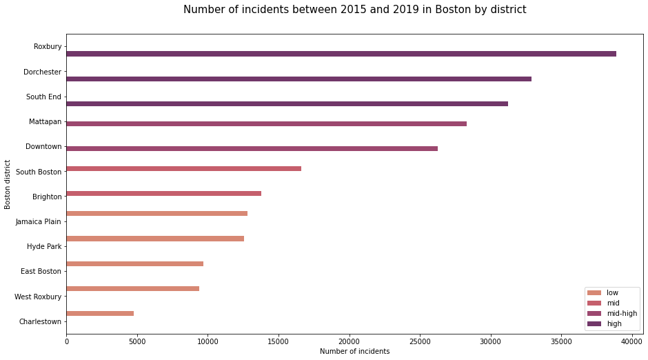

```python
plot_first_graph()
```

**Remark**: we can clearly see that all districts are not affected in the same way by violence. The districts of **Roxbury**, **Dorchester** and **South End** are particularly affected by crime, with more than **29000 incidents** over the past 5 years.

### Let's now have a deeper look at these districts that have different criminality levels. Let's start with the most violent districts.

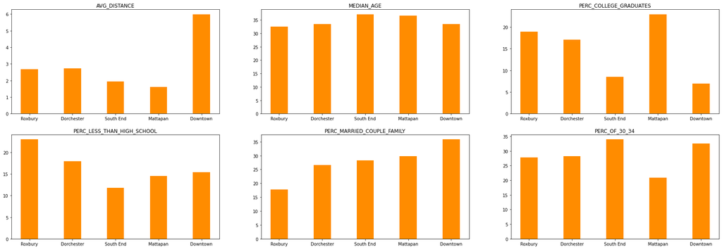

```python
plot_crim_graphs(data, high=True)
```

### How about less violent ones?

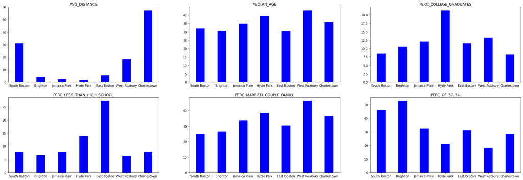

```python
plot_crim_graphs(data, high=False)
```

### Lastly, let's check what is the average distance between the act of violence and the closest police station.

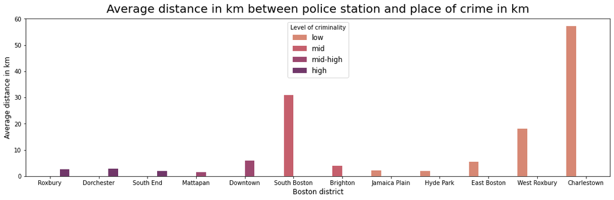

```python
plot_dist_graphs(data)
```

Interestingly, the most violent districts have a smaller distance between place of violence and the police station. It suggests that police presence might enhance violence even more, or that some behaviours are more tackled around police stations in some districts.